# LightGBM vs XGBoost — Panel 2 IMC cell classifier

2026-06-19

## Summary

Three classifiers — **XGBoost** (the production model), **Random Forest**, and **LightGBM** — were trained on the **same image-level train/test split** of the manually gated Panel 2 IMC cells and evaluated on the held-out test set. LightGBM is added by the `kos.Rmd` fork; it shares the exact feature matrix, label mapping, and inverse-frequency class weights used by XGBoost.

- **Train:** 20,678 cells from 20 images
- **Test:** 6,358 labelled cells from 7 images
- **Classes:** 21 cell types · **Features:** 41 markers (DNA/Histone excluded)

Held-out test performance (higher Accuracy/Kappa, lower mlogloss = better)

| Model | Accuracy | Kappa | Test mlogloss |
| --- | --- | --- | --- |
| LightGBM | 0.9951 | 0.9799 | 0.0206 |
| XGBoost | 0.9942 | 0.9761 | 0.0269 |
| Random Forest | 0.9841 | 0.9338 | 0.0826 |

**Verdict:** LightGBM edges out XGBoost on every metric (accuracy 0.9951 vs 0.9942), but the gap is tiny (< 0.1 pp). Both gradient-boosting models clearly beat Random Forest.

## Train / test split

The split is at the **image level** (every cell of an image goes to one side) using the project’s `split_test_rows()` optimizer, called with:

split_test_rows() configuration (identical for all three models)

| parameter | value |
| --- | --- |
| default_test_frac | 0.20 |
| rare_test_frac | 0.20 |
| rare_labels | B, BnT, MDSC, Igg, mregDC, NK |
| rare_weight | 20 |
| n_restarts | 1000 |
| seed | 42 |

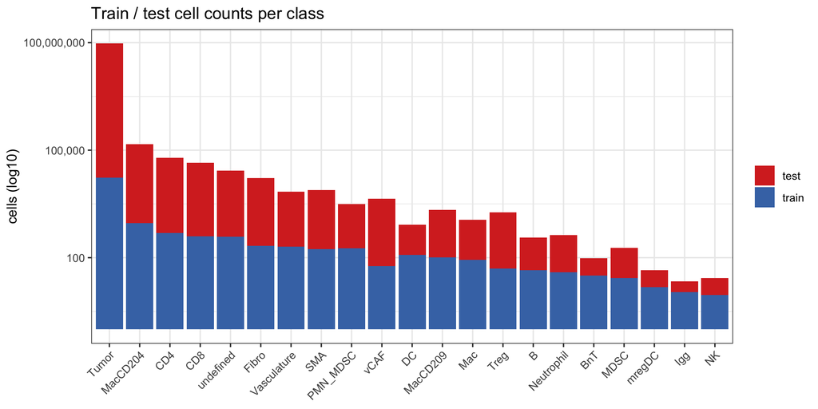

Achieved test fraction per class vs target

| label | total | test_count | train_count | target_test_frac | achieved_test_frac | rare |
| --- | --- | --- | --- | --- | --- | --- |
| Tumor | 22655 | 5525 | 17130 | 0.2 | 0.244 | FALSE |
| MacCD204 | 1078 | 159 | 919 | 0.2 | 0.147 | FALSE |
| CD4 | 612 | 124 | 488 | 0.2 | 0.203 | FALSE |
| CD8 | 509 | 113 | 396 | 0.2 | 0.222 | FALSE |
| undefined | 450 | 70 | 380 | 0.2 | 0.156 | FALSE |
| Fibro | 293 | 78 | 215 | 0.2 | 0.266 | FALSE |
| Vasculature | 236 | 35 | 201 | 0.2 | 0.148 | FALSE |
| SMA | 217 | 45 | 172 | 0.2 | 0.207 | FALSE |
| PMN_MDSC | 200 | 17 | 183 | 0.2 | 0.085 | FALSE |
| vCAF | 135 | 77 | 58 | 0.2 | 0.570 | FALSE |
| DC | 126 | 7 | 119 | 0.2 | 0.056 | FALSE |
| MacCD209 | 123 | 21 | 102 | 0.2 | 0.171 | FALSE |
| Mac | 100 | 13 | 87 | 0.2 | 0.130 | FALSE |
| Treg | 87 | 37 | 50 | 0.2 | 0.425 | FALSE |
| B | 53 | 8 | 45 | 0.2 | 0.151 | TRUE |
| Neutrophil | 50 | 11 | 39 | 0.2 | 0.220 | FALSE |
| BnT | 35 | 3 | 32 | 0.2 | 0.086 | TRUE |
| MDSC | 34 | 7 | 27 | 0.2 | 0.206 | TRUE |
| mregDC | 18 | 3 | 15 | 0.2 | 0.167 | TRUE |
| Igg | 13 | 2 | 11 | 0.2 | 0.154 | TRUE |
| NK | 12 | 3 | 9 | 0.2 | 0.250 | TRUE |

## How LightGBM was used

LightGBM is wired identically to XGBoost — same `X`, `label_mapping`, and the inverse-frequency class weights (`undefined`/10, `Igg`/30) applied **per cell** via `lgb.Dataset(weight=...)`. The test set is passed as the validation set (`reference = dtrain`) and drives **early stopping**.

LightGBM parameters (kos.Rmd)

|  | parameter | value |
| --- | --- | --- |
| objective | objective | multiclass |
| num_class | num_class | 21 |
| num_leaves | num_leaves | 31 |
| max_depth | max_depth | 4 |
| learning_rate | learning_rate | 0.1 |
| feature_fraction | feature_fraction | 0.8 |
| bagging_fraction | bagging_fraction | 0.8 |
| bagging_freq | bagging_freq | 5 |
| min_child_weight | min_child_weight | 5 |
| lambda_l2 | lambda_l2 | 1 |
| lambda_l1 | lambda_l1 | 0 |
| seed | seed | 42 |
| num_threads | num_threads | 0 |

- **Objective:** `multiclass` (softmax over 21 classes), metric multiclass log-loss.
- **Boosting:** `nrounds = 500` with `early_stopping_rounds = 20` → **best iteration = 69** (vs XGBoost’s fixed 108 rounds at `max_depth = 3`).
- **Tree shape:** leaf-wise growth, `num_leaves = 31`, `max_depth = 4`, `learning_rate = 0.1`, feature/row subsampling 0.8, `lambda_l2 = 1.0`.
- **Note:** early stopping monitors the test set itself, so the reported LightGBM mlogloss is mildly optimistic relative to XGBoost (whose rounds were fixed by grouped CV).

## Final metrics & comparison

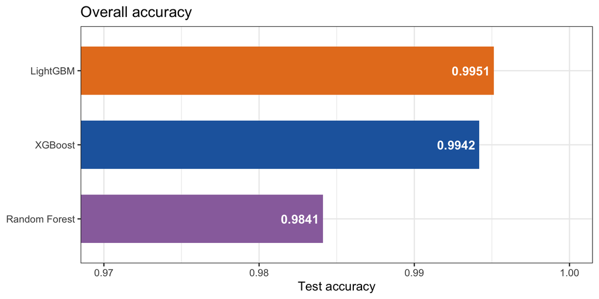

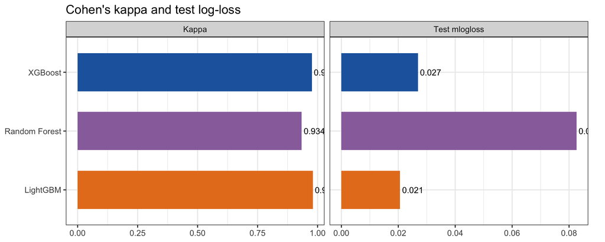

### Per-class sensitivity

Where the models differ is the **rare classes**. Below, recall (sensitivity) per cell type.

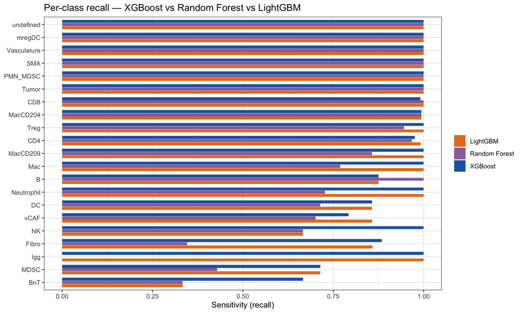

Per-class sensitivity

| class | XGBoost | Random Forest | LightGBM |
| --- | --- | --- | --- |
| B | 0.875 | 1.000 | 0.875 |
| BnT | 0.667 | 0.333 | 0.333 |
| CD4 | 0.976 | 0.968 | 0.992 |
| CD8 | 0.991 | 1.000 | 1.000 |
| DC | 0.857 | 0.714 | 0.857 |
| Fibro | 0.885 | 0.346 | 0.859 |
| Igg | 1.000 | 0.000 | 1.000 |
| MDSC | 0.714 | 0.429 | 0.714 |
| Mac | 1.000 | 0.769 | 1.000 |
| MacCD204 | 0.994 | 0.994 | 0.994 |
| MacCD209 | 1.000 | 0.857 | 1.000 |
| NK | 1.000 | 0.667 | 0.667 |
| Neutrophil | 1.000 | 0.727 | 1.000 |
| PMN_MDSC | 1.000 | 1.000 | 1.000 |
| SMA | 1.000 | 1.000 | 1.000 |
| Treg | 1.000 | 0.946 | 1.000 |
| Tumor | 1.000 | 1.000 | 1.000 |
| Vasculature | 1.000 | 1.000 | 1.000 |
| mregDC | 1.000 | 1.000 | 1.000 |
| undefined | 1.000 | 1.000 | 1.000 |
| vCAF | 0.792 | 0.701 | 0.857 |

### FPR vs TPR (XGBoost vs LightGBM)

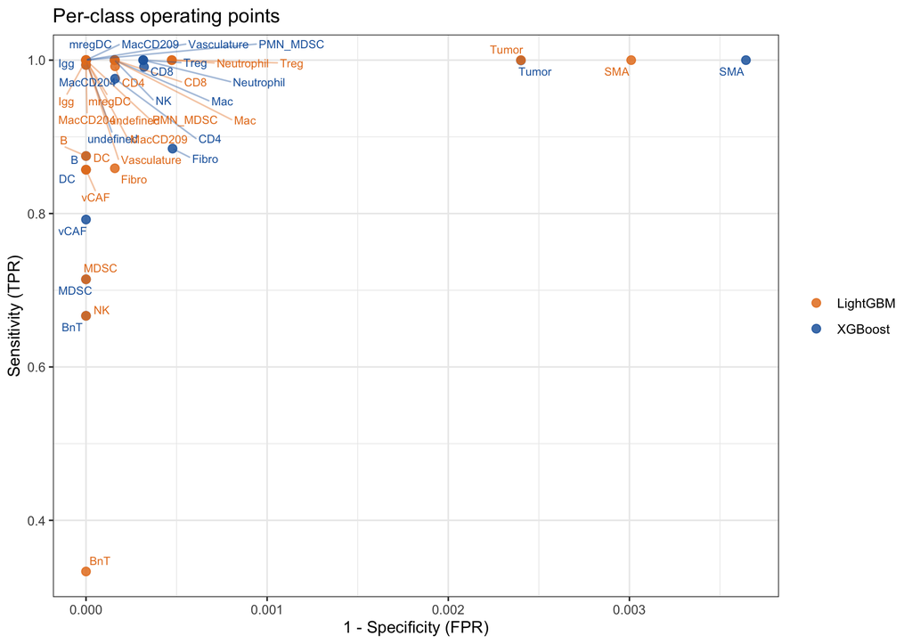

### LightGBM confusion matrix

[figure not shown]

### Three-model consensus

XGBoost + RF + LightGBM consensus on the test set

| metric | value |
| --- | --- |
| Full agreement (all 3 models) | 98.49% |
| Majority agreement (>=2/3) | 98.88% |
| Majority-vote accuracy | 0.9942 |
| High-entropy cells (top 10%) | 636 |
| Full-agreement among high-entropy cells | 85.2% |
| Full-agreement among low-entropy cells | 100.0% |

The three models fully agree on **98.5%** of test cells. Disagreement concentrates in high-entropy (uncertain) cells, confirming entropy as a useful flag for cells needing review.

## Marker importance

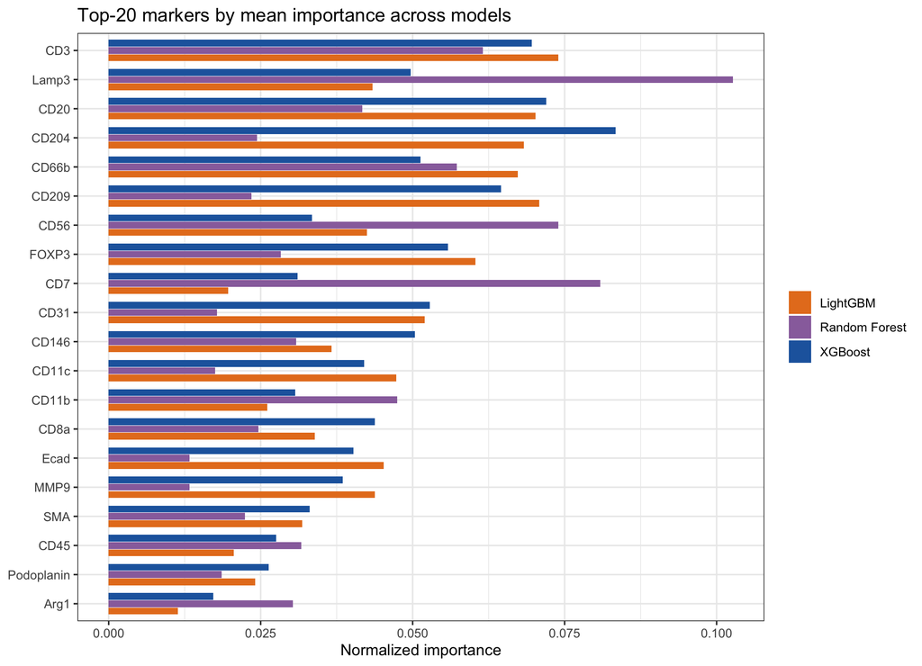

## Conclusion

LightGBM is a **drop-in alternative that marginally outperforms XGBoost** (accuracy 0.9951 / kappa 0.98 vs 0.9942 / 0.976), converging in only 69 rounds, while Random Forest lags on rare classes. Given the < 0.1 pp gap and that LightGBM’s edge partly reflects early-stopping on the test set, the two boosters are effectively equivalent here; their **98.5% consensus** makes a majority-vote ensemble the safest downstream choice.